# Readable Code with Pipes

2017-02-14

# Introduction

This is the sixth post in the series **Data Wrangling with R**. In the previous [post](https://rsquaredacademy.github.io/blog/post/exporting-data-from-r/), we learnt to export data/code from R. In this post, we will learn about pipes.

When you are dealing with a sequence of multiple operations, R code can get a bit cramped and not so easy on the eyes. The magrittr package by Stefan Milton Bache provides pipes enabling us to write R code that is readable.

- especially useful when you have nested functions
- similar in spirit to javascript’s method chaining
- functions taking multiple arguments can be confusing and messy to read
- with magrittr, you program from left to right

R being a functional language, code contains a lot of parentheses. Complex code results in nested functions making them hard to read and maintain.

If you are using tidyverse packages, magrittr will be automatically loaded. We will look at 3 different types of pipes:

- `%>%` : pipe operator - pipe a value forward into an expression or function call
- `%<>%`: compound assignment pipe operator - result assigned to left hand side object instead of returning it
- `%$%` : exposition pipe operator - expose names within left hand side objects to right hand side expressions
- extract data from dataframes, list, matrix etc.: `extract2`, `extract`
- arithmetic operations: `add`, `subtract`, `multiply_by`, `divide_by`, `raise_to_power`
- logical operators: `and`, `or`, `equals`

Let us look at a few examples:

```r
head(ecom, 10)
```

```
## # A tibble: 10 x 11
##       id referrer device bouncers n_visit n_pages duration        country
##    <int>    <chr>  <chr>    <chr>   <int>   <dbl>    <dbl>          <chr>
##  1     1   google laptop     true      10       1      693 Czech Republic
##  2     2    yahoo tablet     true       9       1      459          Yemen
##  3     3   direct laptop     true       0       1      996         Brazil
##  4     4     bing tablet    false       3      18      468          China
##  5     5    yahoo mobile     true       9       1      955         Poland
##  6     6    yahoo laptop    false       5       5      135   South Africa
##  7     7    yahoo mobile     true      10       1       75     Bangladesh
##  8     8   direct mobile     true      10       1      908      Indonesia
##  9     9     bing mobile    false       3      19      209    Netherlands
## 10    10   google mobile     true       6       1      208 Czech Republic
## # ... with 3 more variables: purchase <chr>, order_items <dbl>,
## #   order_value <dbl>
```

```r
ecom %>% head(10)
```

```
## # A tibble: 10 x 11
##       id referrer device bouncers n_visit n_pages duration        country
##    <int>    <chr>  <chr>    <chr>   <int>   <dbl>    <dbl>          <chr>
##  1     1   google laptop     true      10       1      693 Czech Republic
##  2     2    yahoo tablet     true       9       1      459          Yemen
##  3     3   direct laptop     true       0       1      996         Brazil
##  4     4     bing tablet    false       3      18      468          China
##  5     5    yahoo mobile     true       9       1      955         Poland
##  6     6    yahoo laptop    false       5       5      135   South Africa
##  7     7    yahoo mobile     true      10       1       75     Bangladesh
##  8     8   direct mobile     true      10       1      908      Indonesia
##  9     9     bing mobile    false       3      19      209    Netherlands
## 10    10   google mobile     true       6       1      208 Czech Republic
## # ... with 3 more variables: purchase <chr>, order_items <dbl>,
## #   order_value <dbl>
```

```r
y <- ecom$n_pages
y <- sqrt(y)

y <- ecom %$% n_pages
y %<>% sqrt()
```

```r
ecom %>%
  subset(purchase == 'true') %$%
  cor(n_pages, duration)
```

```
## [1] 0.4290905
```

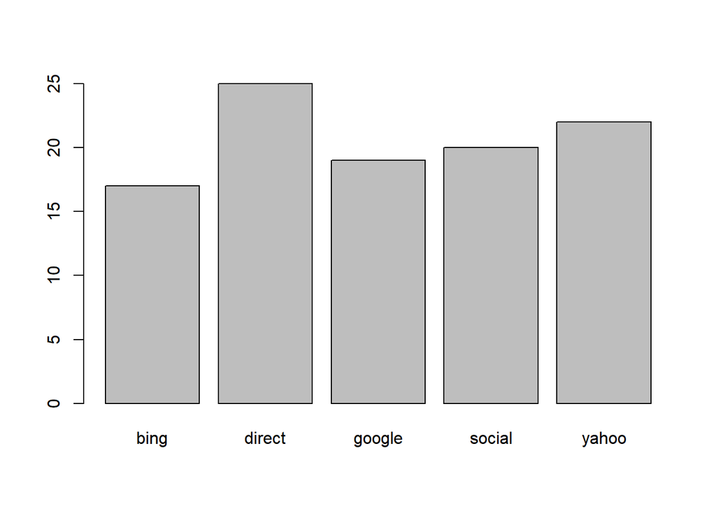

```r
ecom %>%
  subset(purchase == 'true') %>%
  extract('referrer') %>%
  table() %>%
  barplot()
```

```r
ecom %$%
  lm(duration ~ n_pages) %>%
  summary()
```

```
##
## Call:
## lm(formula = duration ~ n_pages)
##
## Residuals:
##     Min      1Q  Median      3Q     Max
## -386.45 -213.03  -38.93  179.31  602.55
##
## Coefficients:
##             Estimate Std. Error t value Pr(>|t|)
## (Intercept)  404.803     11.323  35.750  < 2e-16 ***
## n_pages       -8.355      1.296  -6.449 1.76e-10 ***
## ---
## Signif. codes:  0 '***' 0.001 '**' 0.01 '*' 0.05 '.' 0.1 ' ' 1
##
## Residual standard error: 263.3 on 998 degrees of freedom
## Multiple R-squared:   0.04,  Adjusted R-squared:  0.03904
## F-statistic: 41.58 on 1 and 998 DF,  p-value: 1.756e-10
```

```r
email <- 'jovialcann@anymail.com'

toupper(strtrim(strsplit(email, '@')[[1]][1], 6))
```

```
## [1] "JOVIAL"
```

```r
email %>%
  strsplit(split = '@') %>%
  extract2(1) %>%
  extract(1) %>%
  strtrim(width = 6) %>%
  toupper()
```

```
## [1] "JOVIAL"
```

## Summary

We will learn a better way of dealing with `lists` while exploring the purrr package. The pipe operators work very well with the dplyr verbs we will explore in the next post.